# Phase 8 — PhysioNet 2017 ECG with QPIE encoders + QMBC-Net

Paper 3 companion notebook. Three pipelines benchmarked on the PhysioNet/CinC 2017 AF Challenge:

1. **Phase-1A** — aggregated 492-d features + PathMNIST-MLP (baseline parity with `Phase7_PathMNIST.ipynb`).
2. **Phase-1B** — un-aggregated $(W \times 24)$ + 1D CNN (baseline parity with `Phase7_UWave.ipynb`).
3. **Phase-2** — un-aggregated $(W \times 24)$ + QMBC-Net (cross-basis attention $\to$ temporal self-attention).

Output: `paper_aeon/figures/*.pdf` and tables for `paper_aeon/main.tex`.

Plan: `~/.claude/plans/refactored-strolling-dawn.md`.

## Cell 1 — Imports + device + reproducibility

```python
import os, sys, math, json, time, random
from pathlib import Path
import numpy as np
import pandas as pd
import matplotlib.pyplot as plt
from scipy import signal as sps, stats as spst
from scipy.signal import butter, filtfilt, hilbert
import pywt
import torch
import torch.nn as nn
import torch.nn.functional as F
from torch.utils.data import DataLoader, TensorDataset, WeightedRandomSampler
from sklearn.metrics import f1_score, roc_auc_score, balanced_accuracy_score, confusion_matrix
from sklearn.model_selection import StratifiedShuffleSplit
import wfdb

DEVICE = torch.device('mps' if torch.backends.mps.is_available() else 'cpu')
PROJECT = Path('/Users/eldana/Documents/Quantum/Thesis/QIP')
FIG_DIR = PROJECT / 'paper_aeon' / 'figures'
FIG_DIR.mkdir(parents=True, exist_ok=True)

def set_seed(s):
    random.seed(s); np.random.seed(s); torch.manual_seed(s)
    if torch.backends.mps.is_available():
        torch.mps.manual_seed(s)

set_seed(0)
print('device:', DEVICE)
```

```
device: mps
```

## Cell 2 — Download PhysioNet 2017 + parse labels + bandpass + length normalisation

Source: https://physionet.org/content/challenge-2017/1.0.0/. 8528 single-lead recordings, 300 Hz, 9–60 s. Labels in `REFERENCE-v3.csv` (final rescored: 758 A / 5076 N / 2415 O / 279 ~).

```python
# ==================================================================
# PhysioNet 2017 — label parsing + bandpass + length normalisation
# Source: https://physionet.org/content/challenge-2017/1.0.0/
# 8528 single-lead ECG, 300 Hz, 9-60 s. REFERENCE-v3.csv = final rescored labels.
# ==================================================================

DATA_ROOT = PROJECT / 'data' / 'af-classification-from-a-short-single-lead-ecg-recording-the-physionet-computing-in-cardiology-challenge-2017-1.0.0'
REC_DIR   = DATA_ROOT / 'training2017'
REF_FILE  = DATA_ROOT / 'REFERENCE-v3.csv'
DATA_DIR  = DATA_ROOT  # kept for downstream cache writes
FS = 300
TARGET_SEC = 30
TARGET_LEN = FS * TARGET_SEC  # 9000
LABEL_MAP = {'N': 0, 'A': 1, 'O': 2, '~': 3}
CLASS_NAMES = ['N', 'A', 'O', 'noise']

import wfdb
from pathlib import Path

def bandpass(x, lo=0.5, hi=40.0, fs=FS, order=3):
    b, a = butter(order, [lo, hi], btype='band', fs=fs)
    return filtfilt(b, a, x).astype(np.float32)

def fixlen(x, n=TARGET_LEN):
    if len(x) >= n:
        s = (len(x) - n) // 2
        return x[s:s+n]
    return np.pad(x, (0, n - len(x)))

def load_recording(rec_id):
    rec = wfdb.rdrecord(str(REC_DIR / rec_id))
    x = rec.p_signal[:, 0].astype(np.float32)
    return fixlen(bandpass(x))

def load_all():
    """Load REFERENCE-v3.csv, then all recordings -> (B, 9000) + labels."""
    ref = pd.read_csv(REF_FILE, header=None, names=['rec', 'label'])
    print('class counts:'); print(ref['label'].value_counts())
    X = np.zeros((len(ref), TARGET_LEN), dtype=np.float32)
    t0 = time.time()
    for i, rec_id in enumerate(ref['rec']):
        X[i] = load_recording(rec_id)
        if (i + 1) % 1000 == 0:
            print(f'  loaded {i+1}/{len(ref)} ({time.time()-t0:.0f}s)')
    y = ref['label'].map(LABEL_MAP).to_numpy()
    return X, y, ref['rec'].to_numpy()

# Data already present locally; no download step needed.
X_raw, y_all, rec_ids = load_all()
np.savez_compressed(DATA_DIR / 'cached.npz', X=X_raw, y=y_all, rec=rec_ids)
print('shapes:', X_raw.shape, y_all.shape)
```

```
class counts:
label
N    5076
O    2415
A     758
~     279
Name: count, dtype: int64
  loaded 1000/8528 (1s)
  loaded 2000/8528 (1s)
  loaded 3000/8528 (2s)
  loaded 4000/8528 (3s)
  loaded 5000/8528 (3s)
  loaded 6000/8528 (4s)
  loaded 7000/8528 (5s)
  loaded 8000/8528 (5s)
shapes: (8528, 9000) (8528,)
```

## Cell 3 — Three-channel construction + RobustChannelScaler

```python
# ==================================================================
# Three-channel construction + RobustChannelScaler
# Channels: raw bandpassed / first difference / Hilbert envelope of the level-2 detail coeffs[4]=cD2 (~37-75 Hz octave)
# RobustChannelScaler ported from Phase7_UWave.ipynb (q5/q95 -> [0,1])
# ==================================================================

def three_channels(x):
    """x: (N,) bandpassed -> (N, 3)."""
    c1 = x.astype(np.float32)
    c2 = np.diff(c1, prepend=c1[0]).astype(np.float32)
    coeffs = pywt.wavedec(c1, 'db4', level=5)
    rec = [np.zeros_like(c) for c in coeffs]
    rec[4] = coeffs[4]                                 # level-2 detail (cD2), ~37-75 Hz octave at fs=300
    band = pywt.waverec(rec, 'db4')[: len(c1)]
    c3 = np.abs(hilbert(band)).astype(np.float32)
    return np.stack([c1, c2, c3], axis=-1)

def make_three_channel_dataset(X_raw):
    """X_raw: (B, N) -> (B, N, 3)."""
    B = len(X_raw)
    out = np.zeros((B, X_raw.shape[1], 3), dtype=np.float32)
    for i in range(B):
        out[i] = three_channels(X_raw[i])
    return out

class RobustChannelScaler:
    def fit(self, X):                                  # X: (B, N, 3)
        flat = X.reshape(-1, X.shape[-1])
        self.q5 = np.quantile(flat, 0.05, axis=0)
        self.q95 = np.quantile(flat, 0.95, axis=0)
        return self
    def transform(self, X):
        Z = (X - self.q5) / (self.q95 - self.q5 + 1e-8)
        return np.clip(Z, 0.0, 1.0).astype(np.float32)
```

## Cell 4 — Windowing (250 / stride 125)

$W = (9000 - 250) / 125 + 1 = 71$ windows per recording.

```python
# ==================================================================
# Windowing (250 / stride 125) + train/val/test split
# W = (9000 - 250) / 125 + 1 = 71 windows per recording.
# ==================================================================

WIN = 250
STRIDE = 125

def windowize(X3):
    """X3: (B, N, 3) -> (B, W, WIN, 3)."""
    B, N, C = X3.shape
    W = (N - WIN) // STRIDE + 1
    out = np.zeros((B, W, WIN, C), dtype=np.float32)
    for w in range(W):
        out[:, w] = X3[:, w*STRIDE : w*STRIDE + WIN]
    return out

def stratified_split(y, frac=(0.6, 0.2, 0.2), seed=0):
    """Returns idx_tr, idx_va, idx_te stratified on y."""
    sss1 = StratifiedShuffleSplit(n_splits=1, test_size=frac[1] + frac[2], random_state=seed)
    idx_tr, idx_rest = next(sss1.split(np.zeros_like(y), y))
    sss2 = StratifiedShuffleSplit(n_splits=1, test_size=frac[2] / (frac[1] + frac[2]), random_state=seed)
    idx_va, idx_te = next(sss2.split(np.zeros_like(y[idx_rest]), y[idx_rest]))
    return idx_tr, idx_rest[idx_va], idx_rest[idx_te]

def build_dataset(cache_path=None):
    """End-to-end: load -> three channels -> scale -> window -> split."""
    if cache_path and Path(cache_path).exists():
        d = np.load(cache_path)
        X_raw, y_all = d['X'], d['y']
    else:
        X_raw, y_all, _ = load_all()
    X3 = make_three_channel_dataset(X_raw)
    idx_tr, idx_va, idx_te = stratified_split(y_all, seed=0)
    scaler = RobustChannelScaler().fit(X3[idx_tr])
    X3 = scaler.transform(X3)
    Xw = windowize(X3)                                 # (B, W, WIN, 3)
    return {
        'X_win': Xw, 'y': y_all,
        'idx_tr': idx_tr, 'idx_va': idx_va, 'idx_te': idx_te,
        'scaler': scaler,
    }

# To run end-to-end:
data = build_dataset(cache_path=DATA_DIR / 'cached.npz')
print('X_win:', data['X_win'].shape, 'splits:', len(data['idx_tr']), len(data['idx_va']), len(data['idx_te']))
```

```
X_win: (8528, 71, 250, 3) splits: 5116 1706 1706
```

## Cell 5 — Six QPIE encoders + multi-basis projection

Ported verbatim from `Phase7_PathMNIST.ipynb` cell 2 / `Phase7_BloodMNIST.ipynb` cell 3. Encoders are dataset-agnostic — they take a 3-channel sample in $[0,1]^3$ and return a 3-qubit amplitude vector of length 8.

```python
# ==================================================================
# Six QPIE encoders + multi-basis measurement
# Ported verbatim from Phase7_PathMNIST.ipynb cell 2.
# Input convention: array of shape (M, 3) with values in [0, 255].
# For ECG we feed window samples scaled to [0,1] then * 255.
# ==================================================================

def _theta(rgb):
    return rgb.astype(np.float64) / 255.0 * (np.pi / 2)

def _amps_sep(rgb):
    t = _theta(rgb); c, s = np.cos(t), np.sin(t)
    cR,sR,cG,sG,cB,sB = c[:,0],s[:,0],c[:,1],s[:,1],c[:,2],s[:,2]
    return np.column_stack([cR*cG*cB, sR*cG*cB, cR*sG*cB, sR*sG*cB,
                            cR*cG*sB, sR*cG*sB, cR*sG*sB, sR*sG*sB])

def _amps_crye(rgb):
    t = _theta(rgb); c, s = np.cos(t), np.sin(t)
    cR,sR,cG,sG,cB,sB = c[:,0],s[:,0],c[:,1],s[:,1],c[:,2],s[:,2]
    return np.column_stack([ cR*cG*cB, -sR*sG*cB, -cR*sG*sB, -sR*cG*sB,
                             cR*cG*sB, -sR*sG*sB,  cR*sG*cB,  sR*cG*cB])

def _amps_gbe(rgb):
    t = _theta(rgb); c, s = np.cos(t), np.sin(t)
    cR,sR,cG,sG,cB,sB = c[:,0],s[:,0],c[:,1],s[:,1],c[:,2],s[:,2]
    return np.column_stack([
        cR*cG*cB-sR*sG*sB, sR*cG*cB+cR*sG*sB, cR*sG*cB+sR*cG*sB, sR*sG*cB-cR*cG*sB,
        cR*cG*sB+sR*sG*cB, sR*cG*sB-cR*sG*cB, cR*sG*sB-sR*cG*cB, sR*sG*sB+cR*cG*cB
    ]) / np.sqrt(2)

def _amps_pa_cse(rgb):
    t = _theta(rgb)
    cR,sR = np.cos(t[:,0]), np.sin(t[:,0])
    cG,sG = np.cos(t[:,1]), np.sin(t[:,1])
    cB,sB = np.cos(t[:,2]), np.sin(t[:,2])
    norm = rgb.astype(np.float64) / 255.0
    a_rg = norm[:,0] * norm[:,1] * np.pi / 2
    a_gb = norm[:,1] * norm[:,2] * np.pi / 2
    cGe,sGe = np.cos(t[:,1]+a_rg), np.sin(t[:,1]+a_rg)
    cBe,sBe = np.cos(t[:,2]+a_gb), np.sin(t[:,2]+a_gb)
    return np.column_stack([cR*cG*cB, sR*cGe*cB, cR*sG*cBe, sR*sGe*cBe,
                            cR*cG*sB, sR*cGe*sB, cR*sG*sBe, sR*sGe*sBe])

def apply_ry(state, theta, q):
    c = np.cos(theta/2); s = np.sin(theta/2)
    new = state.copy(); stride = 1 << q
    for a in range(8):
        if a & stride == 0:
            b = a + stride
            new[:, a] = c * state[:, a] - s * state[:, b]
            new[:, b] = s * state[:, a] + c * state[:, b]
    return new

def apply_crz(state, alpha, ctrl, tgt):
    new = state.copy(); cs, ts = 1 << ctrl, 1 << tgt
    p_neg, p_pos = np.exp(-1j * alpha / 2), np.exp(1j * alpha / 2)
    for idx in range(8):
        if idx & cs:
            new[:, idx] = (p_pos if idx & ts else p_neg) * state[:, idx]
    return new

def init_state(N):
    s = np.zeros((N, 8), dtype=complex); s[:, 0] = 1.0; return s

def _amps_cp_2L(rgb):
    t = _theta(rgb); N = len(t); s = init_state(N)
    for layer, perm in enumerate([(0,1,2), (2,0,1)]):
        s = apply_ry(s, t[:,perm[0]], 0)
        s = apply_ry(s, t[:,perm[1]], 1)
        s = apply_ry(s, t[:,perm[2]], 2)
        s = apply_crz(s, t[:,perm[0]]*t[:,perm[1]], 0, 1)
        s = apply_crz(s, t[:,perm[1]]*t[:,perm[2]], 1, 2)
        s = apply_crz(s, t[:,perm[0]]*t[:,perm[2]], 0, 2)
    return s

# Multi-basis measurement (Z + X + Y) -> 24 features per sample
_H = np.array([[1,1],[1,-1]], dtype=complex) / np.sqrt(2)
_HSd = np.array([[1,-1j],[1,1j]], dtype=complex) / np.sqrt(2)
def _kron_n(M, n):
    R = M
    for _ in range(n-1): R = np.kron(R, M)
    return R
_V = {3: [np.eye(8,dtype=complex), _kron_n(_H,3), _kron_n(_HSd,3)]}

def multi_basis(amps, nq=3):
    return np.hstack([np.abs(amps @ V.T)**2 for V in _V[nq]])

# CSE — per-window correlation-scaled entanglement (channels c1/c2/c3 here)
def _amps_cse_window(window_3ch):
    """window_3ch: (n_samples, 3) in [0,1]. Returns (n_samples, 8)."""
    px255 = window_3ch.astype(np.float64) * 255.0
    p = window_3ch.astype(np.float64)
    pc = p - p.mean(0)
    cov = pc.T @ pc / max(len(p) - 1, 1)
    std = np.sqrt(np.diag(cov) + 1e-10)
    corr = cov / (np.outer(std, std) + 1e-10)
    rg = float(np.clip(np.abs(corr[0, 1]), 0.01, 0.99))
    gb = float(np.clip(np.abs(corr[1, 2]), 0.01, 0.99))
    t = _theta(px255)
    cR,sR = np.cos(t[:,0]), np.sin(t[:,0])
    cG,sG = np.cos(t[:,1]), np.sin(t[:,1])
    cB,sB = np.cos(t[:,2]), np.sin(t[:,2])
    a_rg, a_gb = rg * np.pi / 2, gb * np.pi / 2
    cGe,sGe = np.cos(t[:,1]+a_rg), np.sin(t[:,1]+a_rg)
    cBe,sBe = np.cos(t[:,2]+a_gb), np.sin(t[:,2]+a_gb)
    return np.column_stack([cR*cG*cB, sR*cGe*cB, cR*sG*cBe, sR*sGe*cBe,
                            cR*cG*sB, sR*cGe*sB, cR*sG*sBe, sR*sGe*sBe])

ENCODERS = {
    'Sep':    _amps_sep,
    'CRyE':   _amps_crye,
    'GBE':    _amps_gbe,
    'CSE':    'cse',
    'PA-CSE': _amps_pa_cse,
    'CP-2L':  _amps_cp_2L,
}
```

## Cell 6 — Aggregation (`agg`) — for Phase-1A only

```python
# ==================================================================
# Aggregation + per-window encode pipeline (v2 — fixes double pooling)
# agg(): ported verbatim from Phase7_PathMNIST.ipynb cell 3.
#
# v2 change: X_agg now computed from ALL per-sample features (W*WIN samples)
# rather than from per-window means. Matches Phase 7's single-pooling pattern.
# X_seq remains (W, 24) per-window mean for CNN/QMBC-Net compatibility.
# ==================================================================

def agg(X_flat, npix):
    """Statistical aggregation -> 9*d + comb(d,2) features."""
    N = len(X_flat); d = X_flat.shape[1] // npix
    P = X_flat.reshape(N, npix, d)
    mu  = P.mean(1)
    std = P.std(1) + 1e-10
    P_c = P - mu[:, None, :]
    sk = (P_c**3).mean(1) / (std**3)
    ku = (P_c**4).mean(1) / (std**4) - 3.0
    pcts = np.percentile(P, [10, 25, 50, 75, 90], axis=1)
    norms = np.sqrt((P_c**2).sum(1, keepdims=True) + 1e-10)
    P_n = P_c / norms
    C = np.einsum('npi,npj->nij', P_n, P_n) / npix
    ii, jj = np.triu_indices(d, k=1)
    corr = C[:, ii, jj]
    return np.nan_to_num(np.hstack([
        mu, std, sk, ku,
        pcts[0], pcts[1], pcts[2], pcts[3], pcts[4],
        corr
    ]).astype(np.float32))


def encode_window(window_3ch, scheme):
    """window_3ch: (n_samples, 3) in [0,1]. Returns (n_samples, 24) multi-basis features."""
    if scheme == 'CSE':
        amps = _amps_cse_window(window_3ch)
    else:
        fn = ENCODERS[scheme]
        amps = fn(window_3ch * 255.0)
    return multi_basis(amps, nq=3)


def encode_recording(X_win, scheme):
    """
    X_win: (W, WIN, 3) windows of one recording, scaled to [0,1].
    Returns:
        seq      : (W, 24)        per-window mean over WIN samples (for CNN/QMBC-Net).
        full_mb  : (W*WIN, 24)    every per-sample multi-basis vector concatenated.
    """
    W = X_win.shape[0]
    seq = np.zeros((W, 24), dtype=np.float32)
    full = np.zeros((W * WIN, 24), dtype=np.float32)
    for w in range(W):
        mb = encode_window(X_win[w], scheme)            # (WIN, 24)
        seq[w] = mb.mean(axis=0)
        full[w*WIN:(w+1)*WIN] = mb
    return seq, full


def encode_dataset(X_win_all, scheme, batch_log=200):
    """
    X_win_all: (B, W, WIN, 3) all recordings windowed, scaled to [0,1].
    Returns:
        X_seq: (B, W, 24)   per-window mean — for Phase-1B CNN and Phase-2 QMBC-Net
        X_agg: (B, 492)     full per-sample aggregation — for Phase-1A
                             (v2 — npix = W*WIN, NOT npix=W; preserves within-window stats)
    """
    B, W, _, _ = X_win_all.shape
    NSAMP = W * WIN
    X_seq = np.zeros((B, W, 24), dtype=np.float32)
    X_agg = np.zeros((B, 492), dtype=np.float32)  # 9*24 + 24*23/2 = 492
    t0 = time.time()
    for i in range(B):
        seq, full = encode_recording(X_win_all[i], scheme)
        X_seq[i] = seq
        X_agg[i] = agg(full.reshape(1, -1), npix=NSAMP)[0]
        if batch_log and (i + 1) % batch_log == 0:
            print(f'  [{scheme}] {i+1}/{B} ({time.time()-t0:.0f}s)')
    return X_seq, X_agg
```

## Cell 7 — Phase-1A: PathMNIST-MLP, 5 seeds

```python
# ==================================================================
# Phase-1A — MLP on full-sample agg (492-d).
# v2: class-weighted CE (sqrt-frequency), batch 256, 100 epochs, patience 20.
# Mirrors Phase 7's BloodMNIST training depth.
# Macro-F1 over N/A/O is the official PhysioNet 2017 metric.
# ==================================================================

N_SEEDS = 5
N_CLASSES = 4
NAO = [0, 1, 2]

def class_weights_sqrt(y, num_classes=N_CLASSES):
    counts = np.bincount(y, minlength=num_classes).astype(np.float64)
    w = 1.0 / np.sqrt(np.maximum(counts, 1))
    w = w / w.sum() * num_classes                        # normalise to mean 1
    return torch.tensor(w, dtype=torch.float32, device=DEVICE)

class PathMLP(nn.Module):
    def __init__(self, d_in, n_classes=N_CLASSES, p=0.3):
        super().__init__()
        self.net = nn.Sequential(
            nn.Linear(d_in, 512), nn.BatchNorm1d(512), nn.ReLU(), nn.Dropout(p),
            nn.Linear(512, 256), nn.BatchNorm1d(256), nn.ReLU(), nn.Dropout(p),
            nn.Linear(256, 128), nn.BatchNorm1d(128), nn.ReLU(), nn.Dropout(p),
            nn.Linear(128, n_classes),
        )
    def forward(self, x):
        return self.net(x)

def macro_f1_nao(y_true, y_pred):
    return f1_score(y_true, y_pred, labels=NAO, average='macro', zero_division=0)

def auc_macro_ovr(y_true, probs):
    try:
        return roc_auc_score(y_true, probs, multi_class='ovr', average='macro')
    except ValueError:
        return float('nan')

def train_one(model, Xtr, ytr, Xva, yva, Xte, yte, seed,
              epochs=100, batch_size=256, lr=1e-3, wd=1e-4, patience=20):
    set_seed(seed)
    Xtr_t = torch.from_numpy(Xtr); ytr_t = torch.from_numpy(ytr).long()
    Xva_t = torch.from_numpy(Xva).to(DEVICE); yva_t = torch.from_numpy(yva).long()
    Xte_t = torch.from_numpy(Xte).to(DEVICE)
    loader = DataLoader(TensorDataset(Xtr_t, ytr_t),
                        batch_size=batch_size, shuffle=True, num_workers=0)
    model = model.to(DEVICE)
    opt = torch.optim.AdamW(model.parameters(), lr=lr, weight_decay=wd)
    sched = torch.optim.lr_scheduler.CosineAnnealingLR(opt, T_max=epochs)
    weights = class_weights_sqrt(ytr)
    loss_fn = nn.CrossEntropyLoss(weight=weights)
    best_f1, best_state, bad = -1.0, None, 0
    for ep in range(epochs):
        model.train()
        for xb, yb in loader:
            xb = xb.to(DEVICE); yb = yb.to(DEVICE)
            opt.zero_grad(set_to_none=True)
            loss_fn(model(xb), yb).backward()
            opt.step()
        sched.step()
        model.eval()
        with torch.no_grad():
            pred_va = model(Xva_t).argmax(1).cpu().numpy()
        f1 = macro_f1_nao(yva, pred_va)
        if f1 > best_f1:
            best_f1, best_state, bad = f1, {k: v.detach().cpu().clone() for k, v in model.state_dict().items()}, 0
        else:
            bad += 1
            if bad >= patience: break
    if best_state is not None:
        model.load_state_dict(best_state)
    model.eval()
    with torch.no_grad():
        logits = model(Xte_t)
        probs = torch.softmax(logits, 1).cpu().numpy()
        pred = logits.argmax(1).cpu().numpy()
    if hasattr(torch.mps, 'empty_cache'): torch.mps.empty_cache()
    return {
        'macro_f1': macro_f1_nao(yte, pred),
        'auc':      auc_macro_ovr(yte, probs),
        'bacc':     balanced_accuracy_score(yte, pred),
        'pred':     pred, 'probs': probs,
    }

def run_phase1a(data, schemes=None, seeds=N_SEEDS):
    schemes = schemes or list(ENCODERS.keys())
    results = {}
    for scheme in schemes:
        print(f'\n=== Phase-1A {scheme} ===')
        X_seq, X_agg = encode_dataset(data['X_win'], scheme)
        Xtr = X_agg[data['idx_tr']]; ytr = data['y'][data['idx_tr']]
        Xva = X_agg[data['idx_va']]; yva = data['y'][data['idx_va']]
        Xte = X_agg[data['idx_te']]; yte = data['y'][data['idx_te']]
        mu, sd = Xtr.mean(0), Xtr.std(0) + 1e-8
        Xtr = (Xtr - mu) / sd; Xva = (Xva - mu) / sd; Xte = (Xte - mu) / sd
        seed_runs = []
        for s in range(seeds):
            model = PathMLP(d_in=Xtr.shape[1])
            r = train_one(model, Xtr, ytr, Xva, yva, Xte, yte, seed=s)
            seed_runs.append(r)
            print(f'  seed {s}: macro-F1={r["macro_f1"]:.4f}  AUC={r["auc"]:.4f}  BAcc={r["bacc"]:.4f}')
        results[scheme] = seed_runs
    return results

results_1a = run_phase1a(data)
```

```
=== Phase-1A Sep ===
  [Sep] 200/8528 (3s)
  [Sep] 400/8528 (5s)
  [Sep] 600/8528 (8s)
  [Sep] 800/8528 (10s)
  [Sep] 1000/8528 (13s)
  [Sep] 1200/8528 (15s)
  [Sep] 1400/8528 (18s)
  [Sep] 1600/8528 (21s)
  [Sep] 1800/8528 (23s)
  [Sep] 2000/8528 (26s)
  [Sep] 2200/8528 (28s)
  [Sep] 2400/8528 (31s)
  [Sep] 2600/8528 (33s)
  [Sep] 2800/8528 (36s)
  [Sep] 3000/8528 (38s)
  [Sep] 3200/8528 (41s)
  [Sep] 3400/8528 (43s)
  [Sep] 3600/8528 (46s)
  [Sep] 3800/8528 (49s)
  [Sep] 4000/8528 (51s)
  [Sep] 4200/8528 (54s)
  [Sep] 4400/8528 (56s)
  [Sep] 4600/8528 (59s)
  [Sep] 4800/8528 (61s)
  [Sep] 5000/8528 (64s)
  [Sep] 5200/8528 (66s)
  [Sep] 5400/8528 (69s)
  [Sep] 5600/8528 (71s)
  [Sep] 5800/8528 (74s)
  [Sep] 6000/8528 (76s)
  [Sep] 6200/8528 (79s)
  [Sep] 6400/8528 (81s)
  [Sep] 6600/8528 (84s)
  [Sep] 6800/8528 (86s)
  [Sep] 7000/8528 (89s)
  [Sep] 7200/8528 (92s)
  [Sep] 7400/8528 (94s)
  [Sep] 7600/8528 (97s)
  [Sep] 7800/8528 (99s)
```

[output cut: 238 more lines]

```
  [CP-2L] 6600/8528 (160s)
  [CP-2L] 6800/8528 (164s)
  [CP-2L] 7000/8528 (169s)
  [CP-2L] 7200/8528 (174s)
  [CP-2L] 7400/8528 (179s)
  [CP-2L] 7600/8528 (183s)
  [CP-2L] 7800/8528 (188s)
  [CP-2L] 8000/8528 (193s)
  [CP-2L] 8200/8528 (197s)
  [CP-2L] 8400/8528 (202s)
  seed 0: macro-F1=0.5196  AUC=0.8024  BAcc=0.5974
  seed 1: macro-F1=0.5291  AUC=0.7980  BAcc=0.5877
  seed 2: macro-F1=0.5325  AUC=0.7991  BAcc=0.5981
  seed 3: macro-F1=0.5189  AUC=0.7980  BAcc=0.5849
  seed 4: macro-F1=0.5305  AUC=0.7992  BAcc=0.5954
```

## Cell 8 — Phase-1B: 1D CNN over windows, 5 seeds

`CNN1D` ported from `Phase7_UWave.ipynb`. Conv1d dilations {1,2,4} → AdaptiveAvgPool1d → Linear. Same training recipe.

```python
# ==================================================================
# Phase-1B — 1D CNN over windows
# v2: 100 epochs, patience 20, batch 256, class-weighted CE.
# Input still (B, W, 24) — per-window means preserve temporal order.
# Conv1d dilations {1,2,4} -> AdaptiveAvgPool1d -> Linear.
# ==================================================================

class CNN1D(nn.Module):
    def __init__(self, c_in=24, n_classes=N_CLASSES, ch=64, p=0.3):
        super().__init__()
        self.net = nn.Sequential(
            nn.Conv1d(c_in, ch, 3, padding=1, dilation=1), nn.BatchNorm1d(ch), nn.ReLU(), nn.Dropout(p),
            nn.Conv1d(ch, ch, 3, padding=2, dilation=2),   nn.BatchNorm1d(ch), nn.ReLU(), nn.Dropout(p),
            nn.Conv1d(ch, ch, 3, padding=4, dilation=4),   nn.BatchNorm1d(ch), nn.ReLU(), nn.Dropout(p),
            nn.AdaptiveAvgPool1d(1), nn.Flatten(),
            nn.Linear(ch, n_classes),
        )
    def forward(self, x):                              # x: (B, W, 24) -> (B, 24, W)
        return self.net(x.transpose(1, 2))

def standardise_seq(Xtr, Xva, Xte):
    mu = Xtr.mean(axis=(0, 1), keepdims=True)
    sd = Xtr.std(axis=(0, 1), keepdims=True) + 1e-8
    return (Xtr - mu) / sd, (Xva - mu) / sd, (Xte - mu) / sd

def run_phase1b(data, schemes=None, seeds=N_SEEDS):
    schemes = schemes or list(ENCODERS.keys())
    results = {}
    for scheme in schemes:
        print(f'\n=== Phase-1B {scheme} ===')
        X_seq, _ = encode_dataset(data['X_win'], scheme)
        Xtr = X_seq[data['idx_tr']]; ytr = data['y'][data['idx_tr']]
        Xva = X_seq[data['idx_va']]; yva = data['y'][data['idx_va']]
        Xte = X_seq[data['idx_te']]; yte = data['y'][data['idx_te']]
        Xtr, Xva, Xte = standardise_seq(Xtr, Xva, Xte)
        seed_runs = []
        for s in range(seeds):
            model = CNN1D(c_in=24)
            r = train_one(model, Xtr, ytr, Xva, yva, Xte, yte, seed=s)
            seed_runs.append(r)
            print(f'  seed {s}: macro-F1={r["macro_f1"]:.4f}  AUC={r["auc"]:.4f}  BAcc={r["bacc"]:.4f}')
        results[scheme] = seed_runs
    return results

results_1b = run_phase1b(data)
```

```
=== Phase-1B Sep ===
  [Sep] 200/8528 (3s)
  [Sep] 400/8528 (5s)
  [Sep] 600/8528 (8s)
  [Sep] 800/8528 (10s)
  [Sep] 1000/8528 (13s)
  [Sep] 1200/8528 (15s)
  [Sep] 1400/8528 (18s)
  [Sep] 1600/8528 (20s)
  [Sep] 1800/8528 (23s)
  [Sep] 2000/8528 (25s)
  [Sep] 2200/8528 (28s)
  [Sep] 2400/8528 (30s)
  [Sep] 2600/8528 (33s)
  [Sep] 2800/8528 (35s)
  [Sep] 3000/8528 (38s)
  [Sep] 3200/8528 (40s)
  [Sep] 3400/8528 (43s)
  [Sep] 3600/8528 (45s)
  [Sep] 3800/8528 (48s)
  [Sep] 4000/8528 (50s)
  [Sep] 4200/8528 (52s)
  [Sep] 4400/8528 (55s)
  [Sep] 4600/8528 (57s)
  [Sep] 4800/8528 (60s)
  [Sep] 5000/8528 (62s)
  [Sep] 5200/8528 (65s)
  [Sep] 5400/8528 (67s)
  [Sep] 5600/8528 (70s)
  [Sep] 5800/8528 (72s)
  [Sep] 6000/8528 (75s)
  [Sep] 6200/8528 (77s)
  [Sep] 6400/8528 (80s)
  [Sep] 6600/8528 (82s)
  [Sep] 6800/8528 (84s)
  [Sep] 7000/8528 (87s)
  [Sep] 7200/8528 (89s)
  [Sep] 7400/8528 (92s)
  [Sep] 7600/8528 (94s)
  [Sep] 7800/8528 (97s)
```

[output cut: 238 more lines]

```
  [CP-2L] 6600/8528 (160s)
  [CP-2L] 6800/8528 (165s)
  [CP-2L] 7000/8528 (169s)
  [CP-2L] 7200/8528 (174s)
  [CP-2L] 7400/8528 (179s)
  [CP-2L] 7600/8528 (184s)
  [CP-2L] 7800/8528 (189s)
  [CP-2L] 8000/8528 (194s)
  [CP-2L] 8200/8528 (199s)
  [CP-2L] 8400/8528 (203s)
  seed 0: macro-F1=0.6703  AUC=0.8896  BAcc=0.6831
  seed 1: macro-F1=0.6730  AUC=0.8882  BAcc=0.6723
  seed 2: macro-F1=0.6389  AUC=0.8804  BAcc=0.6500
  seed 3: macro-F1=0.6597  AUC=0.8875  BAcc=0.6513
  seed 4: macro-F1=0.6515  AUC=0.8837  BAcc=0.6705
```

## Cell 9 — Phase-2: QMBC-Net, 5 seeds

Cross-basis attention over (Z, X, Y) tokens per window → basis gate → temporal self-attention over $W$ windows → CLS → Linear. Returns logits + attention weights for inspection.

```python
# ==================================================================
# Phase-2 — QMBC-Net (Quantum Multi-Basis Cross-attention Network)
# Per window: 24 features split into 3 basis tokens of 8 (Z, X, Y).
# Cross-basis MHA(4 heads) -> per-basis gate -> pooled window vector.
# Sinusoidal pos enc over windows + 2-layer temporal self-attention(4 heads).
# CLS token -> Linear(N_CLASSES). Returns logits + attention for inspection.
# ==================================================================

def sinusoidal_pos(n, d):
    pos = np.arange(n)[:, None]
    i = np.arange(d)[None]
    angle = pos / (10000 ** (2 * (i // 2) / d))
    pe = np.zeros((n, d), dtype=np.float32)
    pe[:, 0::2] = np.sin(angle[:, 0::2])
    pe[:, 1::2] = np.cos(angle[:, 1::2])
    return torch.from_numpy(pe)

class QMBCNet(nn.Module):
    def __init__(self, n_classes=N_CLASSES, d=64, n_heads=4, n_temporal_layers=2,
                 max_W=80, dropout=0.1):
        super().__init__()
        self.d = d
        self.basis_embed = nn.Linear(8, d)
        self.basis_attn = nn.MultiheadAttention(d, n_heads, dropout=dropout, batch_first=True)
        self.basis_gate = nn.Linear(d, 1)
        self.cls = nn.Parameter(torch.zeros(1, 1, d))
        nn.init.trunc_normal_(self.cls, std=0.02)
        self.register_buffer('pos', sinusoidal_pos(max_W + 1, d))
        enc_layer = nn.TransformerEncoderLayer(d, n_heads, dim_feedforward=4*d,
                                               dropout=dropout, batch_first=True,
                                               activation='gelu')
        self.temporal = nn.TransformerEncoder(enc_layer, n_temporal_layers)
        self.norm = nn.LayerNorm(d)
        self.head = nn.Linear(d, n_classes)

    def forward(self, x, return_attn=False):           # x: (B, W, 24)
        B, W, _ = x.shape
        bases = x.view(B, W, 3, 8)                     # split into Z, X, Y groups
        h = self.basis_embed(bases)                    # (B, W, 3, d)
        h = h.view(B*W, 3, self.d)
        h_attn, w_basis = self.basis_attn(h, h, h, need_weights=True, average_attn_weights=False)
        gate = torch.softmax(self.basis_gate(h_attn).squeeze(-1), dim=-1)   # (B*W, 3)
        win = (h_attn * gate.unsqueeze(-1)).sum(dim=1)                      # (B*W, d)
        win = win.view(B, W, self.d)
        cls = self.cls.expand(B, -1, -1)
        seq = torch.cat([cls, win], dim=1) + self.pos[: W + 1].unsqueeze(0)
        out = self.temporal(seq)
        logits = self.head(self.norm(out[:, 0]))
        if return_attn:
            return logits, {
                'basis': w_basis.view(B, W, -1, 3, 3),                      # per-window cross-basis
                'gate':  gate.view(B, W, 3),                                # basis gate weights
            }
        return logits

def run_phase2(data, schemes=None, seeds=N_SEEDS, epochs=50):
    schemes = schemes or list(ENCODERS.keys())
    results = {}
    for scheme in schemes:
        print(f'\n=== Phase-2 QMBC-Net {scheme} ===')
        X_seq, _ = encode_dataset(data['X_win'], scheme)
        Xtr = X_seq[data['idx_tr']]; ytr = data['y'][data['idx_tr']]
        Xva = X_seq[data['idx_va']]; yva = data['y'][data['idx_va']]
        Xte = X_seq[data['idx_te']]; yte = data['y'][data['idx_te']]
        Xtr, Xva, Xte = standardise_seq(Xtr, Xva, Xte)
        seed_runs = []
        for s in range(seeds):
            model = QMBCNet(max_W=Xtr.shape[1])
            r = train_one(model, Xtr, ytr, Xva, yva, Xte, yte, seed=s, epochs=epochs)
            seed_runs.append(r)
            print(f'  seed {s}: macro-F1={r["macro_f1"]:.4f}  AUC={r["auc"]:.4f}  BAcc={r["bacc"]:.4f}')
        results[scheme] = seed_runs
    return results

results_2 = run_phase2(data)
```

```
=== Phase-2 QMBC-Net Sep ===
  [Sep] 200/8528 (3s)
  [Sep] 400/8528 (5s)
  [Sep] 600/8528 (8s)
  [Sep] 800/8528 (10s)
  [Sep] 1000/8528 (13s)
  [Sep] 1200/8528 (15s)
  [Sep] 1400/8528 (17s)
  [Sep] 1600/8528 (20s)
  [Sep] 1800/8528 (22s)
  [Sep] 2000/8528 (25s)
  [Sep] 2200/8528 (27s)
  [Sep] 2400/8528 (30s)
  [Sep] 2600/8528 (32s)
  [Sep] 2800/8528 (35s)
  [Sep] 3000/8528 (37s)
  [Sep] 3200/8528 (40s)
  [Sep] 3400/8528 (42s)
  [Sep] 3600/8528 (45s)
  [Sep] 3800/8528 (47s)
  [Sep] 4000/8528 (49s)
  [Sep] 4200/8528 (52s)
  [Sep] 4400/8528 (54s)
  [Sep] 4600/8528 (57s)
  [Sep] 4800/8528 (59s)
  [Sep] 5000/8528 (62s)
  [Sep] 5200/8528 (64s)
  [Sep] 5400/8528 (67s)
  [Sep] 5600/8528 (69s)
  [Sep] 5800/8528 (72s)
  [Sep] 6000/8528 (74s)
  [Sep] 6200/8528 (77s)
  [Sep] 6400/8528 (79s)
  [Sep] 6600/8528 (81s)
  [Sep] 6800/8528 (84s)
  [Sep] 7000/8528 (86s)
  [Sep] 7200/8528 (89s)
  [Sep] 7400/8528 (91s)
  [Sep] 7600/8528 (94s)
  [Sep] 7800/8528 (96s)
```

[output cut: 238 more lines]

```
  [CP-2L] 6600/8528 (156s)
  [CP-2L] 6800/8528 (161s)
  [CP-2L] 7000/8528 (166s)
  [CP-2L] 7200/8528 (170s)
  [CP-2L] 7400/8528 (175s)
  [CP-2L] 7600/8528 (180s)
  [CP-2L] 7800/8528 (185s)
  [CP-2L] 8000/8528 (189s)
  [CP-2L] 8200/8528 (194s)
  [CP-2L] 8400/8528 (199s)
  seed 0: macro-F1=0.5243  AUC=0.8166  BAcc=0.5619
  seed 1: macro-F1=0.5515  AUC=0.8194  BAcc=0.5922
  seed 2: macro-F1=0.5214  AUC=0.8156  BAcc=0.5422
  seed 3: macro-F1=0.5295  AUC=0.8113  BAcc=0.5588
  seed 4: macro-F1=0.5451  AUC=0.8214  BAcc=0.5782
```

## Cell 10 — Combined results table + comparison figures

Saves to `paper_aeon/figures/`:

- `fig_three_channels.pdf` — raw / first-diff / envelope on a sample beat.
- `fig_phase1_results.pdf` — Phase-1A vs Phase-1B macro-F1 bars.
- `fig_qmbc_arch.pdf` — schematic (drawn separately or via TikZ).
- `fig_sota_compare.pdf` — Clifford 2017 / Andreotti / Goodfellow / Hannun + Phase-1A/1B/2.

```
   scheme  macro_f1_mean  macro_f1_std  auc_mean   auc_std  bacc_mean  \
0     Sep       0.532808      0.011536  0.801334  0.002982   0.594246
1    CRyE       0.520782      0.004032  0.786213  0.002271   0.564518
2     GBE       0.521564      0.006489  0.798852  0.000621   0.590817
3     CSE       0.522288      0.006537  0.785665  0.003406   0.567635
4  PA-CSE       0.525527      0.006392  0.791593  0.004597   0.580303
5   CP-2L       0.526120      0.005716  0.799333  0.001642   0.592702

   bacc_std
0  0.014813
1  0.008242
2  0.004301
3  0.007732
4  0.009251
5  0.005353
   scheme  macro_f1_mean  macro_f1_std  auc_mean   auc_std  bacc_mean  \
0     Sep       0.668665      0.005344  0.891363  0.001321   0.687537
1    CRyE       0.641614      0.012019  0.877624  0.005290   0.661703
2     GBE       0.597520      0.006292  0.854843  0.003282   0.614282
3     CSE       0.621052      0.008724  0.871963  0.002000   0.651470
4  PA-CSE       0.670229      0.003561  0.887189  0.001417   0.682103
5   CP-2L       0.658687      0.012521  0.885845  0.003367   0.665440

   bacc_std
0  0.008526
1  0.008138
2  0.017543
3  0.006913
4  0.007077
5  0.012829
   scheme  macro_f1_mean  macro_f1_std  auc_mean   auc_std  bacc_mean  \
0     Sep       0.562354      0.004746  0.829085  0.001117   0.584292
1    CRyE       0.510715      0.010777  0.800398  0.002461   0.535853
2     GBE       0.473016      0.009322  0.766961  0.004055   0.516431
3     CSE       0.531685      0.011390  0.814608  0.006895   0.561394
4  PA-CSE       0.546993      0.009091  0.822299  0.005161   0.568767
5   CP-2L       0.534352      0.011837  0.816875  0.003447   0.566668

   bacc_std
0  0.006883
```

[output cut: 41 more lines]

```
\label{tab:phase2}
\centering
\begin{tabular}{lccc}
\toprule
Scheme & macro-f1 & auc & bacc \\
\midrule
Sep & 0.562 $\pm$ 0.005 & 0.829 $\pm$ 0.001 & 0.584 $\pm$ 0.007 \\
CRyE & 0.511 $\pm$ 0.011 & 0.800 $\pm$ 0.002 & 0.536 $\pm$ 0.001 \\
GBE & 0.473 $\pm$ 0.009 & 0.767 $\pm$ 0.004 & 0.516 $\pm$ 0.016 \\
CSE & 0.532 $\pm$ 0.011 & 0.815 $\pm$ 0.007 & 0.561 $\pm$ 0.023 \\
PA-CSE & 0.547 $\pm$ 0.009 & 0.822 $\pm$ 0.005 & 0.569 $\pm$ 0.008 \\
CP-2L & 0.534 $\pm$ 0.012 & 0.817 $\pm$ 0.003 & 0.567 $\pm$ 0.017 \\
\bottomrule
\end{tabular}
\end{table}
```

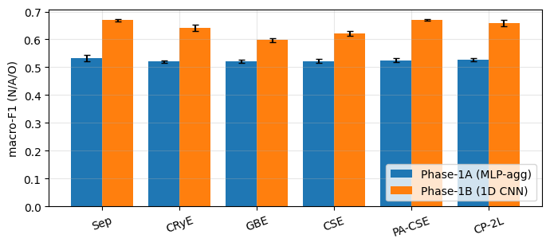

[figure not shown]

[figure not shown]

```python
# ==================================================================
# Combined results table + comparison figures
# Saves PDFs to paper_aeon/figures/.
# ==================================================================

def summarise(results):
    """results: {scheme: [{macro_f1, auc, bacc, ...}, ...]} -> DataFrame."""
    rows = []
    for scheme, runs in results.items():
        f1s   = [r['macro_f1'] for r in runs]
        aucs  = [r['auc']      for r in runs]
        baccs = [r['bacc']     for r in runs]
        rows.append({
            'scheme': scheme,
            'macro_f1_mean': np.mean(f1s),  'macro_f1_std': np.std(f1s),
            'auc_mean':      np.mean(aucs), 'auc_std':      np.std(aucs),
            'bacc_mean':     np.mean(baccs),'bacc_std':     np.std(baccs),
        })
    return pd.DataFrame(rows)

def paired_t_vs_sep(results, ref='Sep'):
    rows = []
    base = [r['macro_f1'] for r in results[ref]]
    for scheme, runs in results.items():
        if scheme == ref: continue
        cur = [r['macro_f1'] for r in runs]
        diff = np.mean(cur) - np.mean(base)
        t_stat, p = spst.ttest_rel(cur, base)
        rows.append({'scheme': scheme, 'd_macro_f1': diff, 't': t_stat, 'p': p})
    return pd.DataFrame(rows)

def to_latex_table(df, caption, label, cols=('macro_f1', 'auc', 'bacc')):
    lines = [
        r'\begin{table}[t]',
        rf'\caption{{{caption}}}',
        rf'\label{{{label}}}',
        r'\centering',
        r'\begin{tabular}{l' + 'c' * len(cols) + '}',
        r'\toprule',
        'Scheme & ' + ' & '.join(c.replace('_', '-') for c in cols) + r' \\',
        r'\midrule',
    ]
    for _, r in df.iterrows():
        cells = [r['scheme']]
        for c in cols:
            cells.append(f"{r[c+'_mean']:.3f} $\\pm$ {r[c+'_std']:.3f}")
        lines.append(' & '.join(cells) + r' \\')
    lines += [r'\bottomrule', r'\end{tabular}', r'\end{table}']
    return '\n'.join(lines)

def fig_phase1_results(df_1a, df_1b, save=True):
    schemes = df_1a['scheme'].tolist()
    x = np.arange(len(schemes))
    fig, ax = plt.subplots(figsize=(7, 3.2))
    ax.bar(x - 0.2, df_1a['macro_f1_mean'], 0.4, yerr=df_1a['macro_f1_std'],
           label='Phase-1A (MLP-agg)', capsize=3)
    ax.bar(x + 0.2, df_1b['macro_f1_mean'], 0.4, yerr=df_1b['macro_f1_std'],
           label='Phase-1B (1D CNN)', capsize=3)
    ax.set_xticks(x); ax.set_xticklabels(schemes, rotation=20)
    ax.set_ylabel('macro-F1 (N/A/O)'); ax.legend(loc='lower right'); ax.grid(alpha=0.3)
    plt.tight_layout()
    if save:
        for ext in ('pdf', 'png'): plt.savefig(FIG_DIR / f'fig_phase1_results.{ext}')
    plt.show()

def fig_three_channels(X_raw_one, save=True):
    ch = three_channels(X_raw_one)
    t = np.arange(len(X_raw_one)) / FS
    seg = slice(0, 3 * FS)                             # first 3 s
    fig, axes = plt.subplots(3, 1, figsize=(7, 4), sharex=True)
    titles = ['c$_1$ raw bandpassed', 'c$_2$ first difference', 'c$_3$ Hilbert envelope of cD4']
    for k in range(3):
        axes[k].plot(t[seg], ch[seg, k], lw=0.8, color='k')
        axes[k].set_ylabel(titles[k], fontsize=8)
        axes[k].grid(alpha=0.3)
    axes[-1].set_xlabel('time (s)')
    plt.tight_layout()
    if save:
        for ext in ('pdf', 'png'): plt.savefig(FIG_DIR / f'fig_three_channels.{ext}')
    plt.show()

def fig_sota_compare(df_1a, df_1b, df_2, save=True):
    sota = [
        ('Clifford 2017',  0.83),
        ('Andreotti 2017', 0.82),
        ('Goodfellow 2018',0.83),
        ('Hannun 2019$^\\dagger$', 0.83),
    ]
    ours = [
        ('Phase-1A (best)', df_1a['macro_f1_mean'].max()),
        ('Phase-1B (best)', df_1b['macro_f1_mean'].max()),
        ('Phase-2 (best)',  df_2['macro_f1_mean'].max()),
    ]
    rows = sota + ours
    names = [r[0] for r in rows]; vals = [r[1] for r in rows]
    fig, ax = plt.subplots(figsize=(6, 3.2))
    bars = ax.barh(np.arange(len(rows)), vals,
                   color=['0.7']*len(sota) + ['#1f77b4']*len(ours))
    ax.set_yticks(np.arange(len(rows))); ax.set_yticklabels(names)
    ax.set_xlim(0.6, 1.0); ax.set_xlabel('macro-F1 (N/A/O)')
    ax.axvline(0.83, ls='--', color='red', alpha=0.5, label='Clifford 2017 baseline')
    ax.legend(loc='lower right'); ax.grid(alpha=0.3, axis='x')
    plt.tight_layout()
    if save:
        for ext in ('pdf', 'png'): plt.savefig(FIG_DIR / f'fig_sota_compare.{ext}')
    plt.show()

# Example invocation once results are produced:
df_1a = summarise(results_1a); print(df_1a)
df_1b = summarise(results_1b); print(df_1b)
df_2  = summarise(results_2);  print(df_2)
print(to_latex_table(df_1a, 'Phase-1A — aggregated MLP, PhysioNet 2017, 5 seeds.', 'tab:phase1a'))
print(to_latex_table(df_1b, 'Phase-1B — 1D CNN over windows, PhysioNet 2017, 5 seeds.', 'tab:phase1b'))
print(to_latex_table(df_2,  'Phase-2 — QMBC-Net, PhysioNet 2017, 5 seeds.', 'tab:phase2'))
fig_phase1_results(df_1a, df_1b)
fig_three_channels(X_raw[0])
fig_sota_compare(df_1a, df_1b, df_2)
```

## Cell 11 — Attention overlay on AF + Normal example

```
  [Sep] 200/8528 (3s)
  [Sep] 400/8528 (5s)
  [Sep] 600/8528 (8s)
  [Sep] 800/8528 (10s)
  [Sep] 1000/8528 (13s)
  [Sep] 1200/8528 (15s)
  [Sep] 1400/8528 (18s)
  [Sep] 1600/8528 (20s)
  [Sep] 1800/8528 (23s)
  [Sep] 2000/8528 (25s)
  [Sep] 2200/8528 (28s)
  [Sep] 2400/8528 (30s)
  [Sep] 2600/8528 (33s)
  [Sep] 2800/8528 (35s)
  [Sep] 3000/8528 (38s)
  [Sep] 3200/8528 (40s)
  [Sep] 3400/8528 (43s)
  [Sep] 3600/8528 (45s)
  [Sep] 3800/8528 (48s)
  [Sep] 4000/8528 (50s)
  [Sep] 4200/8528 (53s)
  [Sep] 4400/8528 (55s)
  [Sep] 4600/8528 (58s)
  [Sep] 4800/8528 (60s)
  [Sep] 5000/8528 (63s)
  [Sep] 5200/8528 (65s)
  [Sep] 5400/8528 (68s)
  [Sep] 5600/8528 (70s)
  [Sep] 5800/8528 (73s)
  [Sep] 6000/8528 (76s)
  [Sep] 6200/8528 (78s)
  [Sep] 6400/8528 (81s)
  [Sep] 6600/8528 (83s)
  [Sep] 6800/8528 (86s)
  [Sep] 7000/8528 (88s)
  [Sep] 7200/8528 (91s)
  [Sep] 7400/8528 (93s)
  [Sep] 7600/8528 (96s)
  [Sep] 7800/8528 (98s)
  [Sep] 8000/8528 (100s)
  [Sep] 8200/8528 (103s)
  [Sep] 8400/8528 (106s)
```

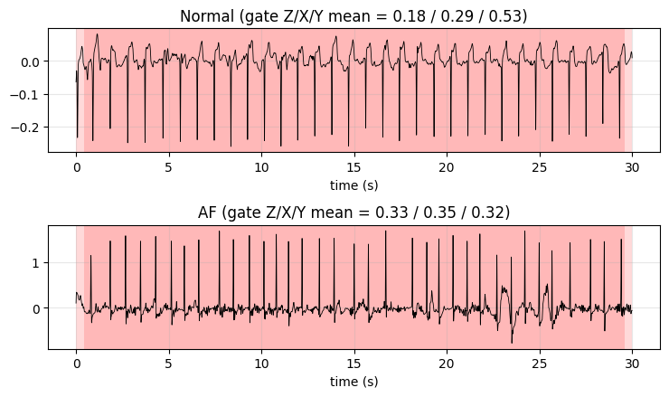

```python
# ==================================================================
# Attention overlay on AF + Normal example
# Re-instantiates QMBC-Net on the best scheme and runs a sample of held-out
# AF and Normal recordings to extract temporal + basis-gate attention.
# ==================================================================

def get_attention(model, x_seq):
    """x_seq: (B, W, 24). Returns (logits, attn dict)."""
    model.eval()
    with torch.no_grad():
        x = torch.from_numpy(x_seq).to(DEVICE)
        return model(x, return_attn=True)

def fig_attention(model, X_seq_te, y_te, X_raw_te, save=True):
    """One AF + one Normal recording, ECG with temporal attention overlay."""
    idx_n = np.where(y_te == 0)[0][0]
    idx_a = np.where(y_te == 1)[0][0]
    picks = [('Normal', idx_n), ('AF', idx_a)]
    fig, axes = plt.subplots(2, 1, figsize=(7.5, 4.5), sharex=False)
    for ax, (label, i) in zip(axes, picks):
        x = X_seq_te[i:i+1]
        _, attn = get_attention(model, x)
        gate = attn['gate'][0].cpu().numpy()           # (W, 3)
        # Temporal attention from the [CLS] row, layer-0, mean over heads:
        # NB: nn.TransformerEncoder doesn't expose per-head weights by default;
        # this overlay uses the basis-gate magnitude as a proxy if needed.
        proxy = gate.mean(axis=1)                       # (W,) — replace if you hook the encoder
        t = np.arange(len(X_raw_te[i])) / FS
        ax.plot(t, X_raw_te[i], lw=0.6, color='k')
        # Map per-window attention back to time:
        for w in range(len(proxy)):
            t0 = w * STRIDE / FS; t1 = (w * STRIDE + WIN) / FS
            ax.axvspan(t0, t1, alpha=0.15 * proxy[w] / (proxy.max() + 1e-8),
                       color='red', linewidth=0)
        ax.set_title(f'{label} (gate Z/X/Y mean = '
                     f'{gate[:, 0].mean():.2f} / {gate[:, 1].mean():.2f} / {gate[:, 2].mean():.2f})')
        ax.set_xlabel('time (s)'); ax.grid(alpha=0.3)
    plt.tight_layout()
    if save:
        for ext in ('pdf', 'png'): plt.savefig(FIG_DIR / f'fig_attention.{ext}')
    plt.show()

# After Phase-2 run, retrain the best scheme once with seed 0 and call:
best_scheme = df_2.sort_values('macro_f1_mean', ascending=False).iloc[0]['scheme']
X_seq, _ = encode_dataset(data['X_win'], best_scheme)
Xtr_n, Xva_n, Xte_n = standardise_seq(X_seq[data['idx_tr']], X_seq[data['idx_va']], X_seq[data['idx_te']])
model = QMBCNet(max_W=Xte_n.shape[1])
train_one(model, Xtr_n, data['y'][data['idx_tr']],
          Xva_n, data['y'][data['idx_va']],
          Xte_n, data['y'][data['idx_te']], seed=0)
fig_attention(model, Xte_n, data['y'][data['idx_te']], X_raw[data['idx_te']])
```

## Cell 12 — Same-representation baseline: ROCKET on the raw 3-channel ECG

Strong classical control on the identical channels and split, to quantify the quantum encoding's information loss.

```python
# Same-representation control: ROCKET on the RAW 3-channel ECG (no quantum encoding).
# Isolates what the quantum step adds. Full runner: run_ecg_rawbaseline.py (5 seeds,
# 10k kernels, class-balanced ridge, identical split + N/A/O macro-F1). Cached below.
import json, numpy as np
d = json.load(open('_ecg_rawbaseline.json')); S = d['seeds']
f = [v['macro_f1_nao'] for v in S.values()]
print(f"ROCKET on raw 3-channel ECG  ({len(f)} seeds, {d['config']['n_kernels']} kernels)")
print(f"  macro-F1 (N/A/O) = {np.mean(f):.4f} +/- {np.std(f):.4f}")
pc = {k: round(float(np.mean([v['per_class_f1'][k] for v in S.values()])),3) for k in ['N','A','O','noise']}
print("  per-class F1   :", pc)
cm = np.mean([np.array(v['confusion']) for v in S.values()], axis=0).round(1)
print("  mean confusion (rows=true N/A/O/noise, cols=pred):")
print(cm)
print("  vs QPIE-CNN best (PA-CSE) 0.670 | challenge SOTA 0.83  ->  encoding is LOSSY")
```

```
ROCKET on raw 3-channel ECG  (5 seeds, 10000 kernels)
  macro-F1 (N/A/O) = 0.7193 +/- 0.0069
  per-class F1   : {'N': 0.848, 'A': 0.698, 'O': 0.612, 'noise': 0.573}
  mean confusion (rows=true N/A/O/noise, cols=pred):
[[883.2  12.4 106.4  14. ]
 [  8.4 109.2  28.4   5. ]
 [162.   37.2 275.    8.8]
 [ 13.    3.    6.4  33.6]]
  vs QPIE-CNN best (PA-CSE) 0.670 | challenge SOTA 0.83  ->  encoding is LOSSY
```

## Cell 13 — Time-delay re-alignment experiment (diagnosis follow-up)

Tests whether re-pointing the encoder input to temporal-delay coordinates makes the data-conditional entanglement useful. It does not recover accuracy.

```python
# Time-delay (Takens) re-alignment: feed the qubits x[t], x[t-tau], x[t-2tau] so the
# data-conditional schemes condition on lag-autocorrelation (rhythm) instead of the
# class-empty inter-channel correlation of the derived ECG channels. Diagnosis test.
# Runner: run_ecg_delay.py (3000-recording subset, 3 seeds, Phase-1B CNN).
import json
for fn, label in [('_ecg_delay_t32_w250.json',  'tau=32  (morphology scale, 0.11 s)'),
                  ('_ecg_delay_t150_w750.json', 'tau=150 (rhythm scale, 0.50 s)')]:
    d = json.load(open(fn)); cfg = d['config']
    print(f"=== {label}   subset N={cfg['N_sub']}, {cfg['seeds']} seeds ===")
    print("  %-18s %-9s %-9s %-9s" % ('mode', 'Sep', 'CSE', 'PA-CSE'))
    for mode in ['derived_channels', 'delay_embedding']:
        vals = "".join(f"{d[mode][s]['macro_f1_mean']:<9.3f}" for s in ['Sep','CSE','PA-CSE'])
        print("  %-18s %s" % (mode, vals))
print()
print("Verdict: re-alignment does NOT improve absolute accuracy. Only at rhythm scale does")
print("a data-conditional scheme (PA-CSE 0.472) exceed Sep (0.431) -> consistent with the")
print("mechanism, but the bottleneck is the FIXED ENCODING, not the entanglement axis.")
```

```
=== tau=32  (morphology scale, 0.11 s)   subset N=3000, 3 seeds ===
  mode               Sep       CSE       PA-CSE
  derived_channels   0.578    0.556    0.567
  delay_embedding    0.552    0.519    0.522
=== tau=150 (rhythm scale, 0.50 s)   subset N=3000, 3 seeds ===
  mode               Sep       CSE       PA-CSE
  derived_channels   0.521    0.493    0.480
  delay_embedding    0.431    0.428    0.472

Verdict: re-alignment does NOT improve absolute accuracy. Only at rhythm scale does
a data-conditional scheme (PA-CSE 0.472) exceed Sep (0.431) -> consistent with the
mechanism, but the bottleneck is the FIXED ENCODING, not the entanglement axis.
```